# Assignment 2 - Elementary Probability and Information Theory

# Boise State University DL - Dr. Kennington

### Instructions and Hints:

- This notebook loads some data into a `pandas` dataframe, then does a small amount of preprocessing. Make sure your data can load by stepping through all of the cells up until question 1.
- Most of the questions require you to write some code. In many cases, you will write some kind of probability function like we did in class using the data.
- Some of the questions only require you to write answers, so be sure to change the cell type to markdown or raw text
- Don't worry about normalizing the text this time (e.g., lowercase, etc.). Just focus on probabilies.
- Most questions can be answered in a single cell, but you can make as many additional cells as you need.
- When complete, please export as HTML. Follow the instructions on the corresponding assignment Trello card for submitting your assignment.

```python
import pandas as pd

data = pd.read_csv('pnp-train.txt',delimiter='\t',encoding='latin-1', # utf8 encoding didn't work for this
                  names=['type','name']) # supply the column names for the dataframe

# this next line creates a new column with the lower-cased first word
data['first_word'] = data['name'].map(lambda x: x.lower().split()[0])
```

```python
data[:10]
```

|  | type | name | first_word |
| --- | --- | --- | --- |
| 0 | drug | Dilotab | dilotab |
| 1 | movie | Beastie Boys: Live in Glasgow | beastie |
| 2 | person | Michelle Ford-Eriksson | michelle |
| 3 | place | Ramsbury | ramsbury |
| 4 | place | Market Bosworth | market |
| 5 | drug | Cyanide Antidote Package | cyanide |
| 6 | person | Bill Johnson | bill |
| 7 | place | Ettalong | ettalong |
| 8 | movie | The Suicide Club | the |
| 9 | place | Pézenas | pézenas |

```python
data.describe()
```

|  | type | name | first_word |
| --- | --- | --- | --- |
| count | 21001 | 21001 | 21001 |
| unique | 5 | 20992 | 13703 |
| top | movie | Epinal | the |
| freq | 6262 | 2 | 635 |

## 1. Write a probability function/distribution $P(T)$ over the types.

Hints:

- The Counter library might be useful: `from collections import Counter`
- Write a function `def P(T='')` that returns the probability of the specific value for T
- You can access the types from the dataframe by calling `data['type']`

```python
from collections import Counter

def P(T = ''):
    # This is a way to make static local variables.
    if P.counter == None:
        P.counter = Counter()
        for ttype in data['type']:
            P.counter[ttype] += 1
    return float(P.counter[T]) / float(data.count()[0])
P.counter = None
```

## 2. What is `P(T='movie')` ?

```python
# expected 0.29817627732012764
P('movie')
```

```
0.29817627732012764
```

## 3. Show that your probability distribution sums to one.

```python
import numpy as np
np.sum([P(x) for x in P.counter])
```

```
1.0
```

## 4. Write a joint distribution using the type and the first word of the name

Hints:

- The function is $P2(T,W_1)$
- You will need to count up types AND the first words, for example: ('person','bill)
- Using the zip function was useful for me here

```python
def P2(T = '', W1 = ''):
    if P2.counter == None:
        P2.counter = Counter()
        iterator = zip(data['type'], data['first_word'])
        for i in iterator:
            P2.counter[i] += 1
    return float(P2.counter[(T, W1)]) / float(data.count()[0])
P2.counter = None
```

## 5. What is P2(T='person', W1='bill')? What about P2(T='movie',W1='the')?

```python
# expected: 0.00047616780153326033
P2(T='person', W1='bill')
```

```
0.00047616780153326033
```

```python
# expected: 0.02747488214846912
P2(T='movie',W1='the')
```

```
0.02747488214846912
```

## 6. Show that your probability distribution P(T,W1) sums to one.

```python
# This is where it starts getting slow to run. I think Python's map lookup could be faster,
# or maybe I haven't picked the most efficient method to implement the P2 function.

# If it isn't in the counter, don't bother because the probability will be 0.
np.sum([P2(ttype, first_word) for (ttype, first_word) in P2.counter])
```

```
1.0
```

## 7. Make a new function Q(T) from marginalizing over P(T,W1) and make sure that Q(T) sums to one.

Hints:

- Your Q function will call P(T,W1)
- Your check for the sum to one should be the same answer as Question 3, only it calls Q instead of P.

```python
def Q(T = ''):
    return np.sum([P2(T, first_word) for first_word in data['first_word'].unique()])
```

```python
# expected 0.2981762773201236
Q(T = 'movie')
```

```
0.29817627732012764
```

```python
# expected 1.0
np.sum([Q(ttype) for ttype in data['type'].unique()])
```

```
1.0
```

## 8. What is the KL Divergence of your Q function and your P function for Question 1?

- Even if you know the answer, you still need to write code that computes it.

```python
# expected -0.0
import math
np.sum([P(ttype) * (math.log(P(ttype)) - math.log(Q(ttype))) for ttype in data['type'].unique()])
```

```
0.0
```

## 9. Convert from P(T,W1) to P(W1|T)

Hints:

- Just write a comment cell, no code this time.
- Note that $P(T,W1) = P(W1,T)$

## $P(W_1|T) = \frac{P(W_1,T)}{P(T)}$

## 10. Write a function `Pwt` (that calls the functions you already have) to compute $P(W_1|T)$.

- This will be something like the multiplication rule, but you may need to change something

```python
def Pwt(W1 = '', T = ''):
    return P2(W1 = W1, T = T) / P(T = T)
```

## 11. What is P(W1='the'|T='movie')?

```python
# expected 0.09214308527626956
# This means about 9% of movies in the dataset start with the word "the."
Pwt(W1 = 'the', T = 'movie')
```

```
0.09214308527626956
```

## 12. Use Baye's rule to convert from P(W1|T) to P(T|W1). Write a function Ptw to reflect this.

Hints:

- Call your other functions.
- You may need to write a function for P(W1) and you may need a new counter for `data['first_word']`

```python
def Ptw(T = '', W1 = ''):
    if Ptw.counter == None:
        Ptw.counter = Counter()
        for first_word in data['first_word']:
            Ptw.counter[first_word] += 1
    P_W1 = float(Ptw.counter[W1]) / float(data.count()[0])
    return (Pwt(W1 = W1, T = T) * P(T = T)) / P_W1
Ptw.counter = None
```

## 13

### What is P(T='movie'|W1='the')?

### What about P(T='person'|W1='the')?

### What about P(T='drug'|W1='the')?

### What about P(T='place'|W1='the')

### What about P(T='company'|W1='the')

```python
# This means that about 90% of the entries starting with "the" are movies.
Ptw(T = 'movie', W1 = 'the')
```

```
0.9086614173228347
```

```python
Ptw(T = 'person', W1 = 'the')
```

```
0.0
```

```python
Ptw(T = 'drug', W1 = 'the')
```

```
0.0
```

```python
Ptw(T = 'place', W1 = 'the')
```

```
0.0015748031496062992
```

```python
Ptw(T = 'company', W1 = 'the')
```

```
0.08976377952755905
```

## 14 Given this, if the word 'the' is found in a name, what is the most likely type?

movie

## 15. Is Ptw(T='movie'|W1='the') the same as Pwt(W1='the'|T='movie') the same? Why or why not?

No. The first function is answering the question, "If we encounter a name with the first word 'the,' what is the chance that that entry will be a movie?" and the second function is answering the question, "If we encounter a movie, what is the chance that its name will start with the word 'the'?" They are two different questions, and they consider different portions of the table. To see why that is, we can outline a way to do the functions without using the formulae above. To implement the first function, consider only the entries of the data with names that start with "the," then find the probability of "movie" being the type **with respect to only entries with names that start with "the."** To implement the second function, consider only the entries of the data whose type is "movie," then find the probability of "the" being the first word, **with respect to only entries with type "movie."**

## 16. Do you think modeling Ptw(T|W1) would be better with a continuous function like a Gaussian? Why or why not?

How would you map the discrete words to continuous real numbers? It doesn't make much sense, and I don't think it would be a good idea.

## 17. Determine the right probability distribution

- Load the `rivers.csv` file and print out a histogram
- Which disitrbutions do you think would fit the data for the `x` column? Here is a list: https://en.wikipedia.org/wiki/Category:Continuous_distributions
- Hint: look at some of the exponential distributions, and maybe the Pareto
- Use the principle of Maximum Entropy to detemrine which of the two distributions would best fit your data (you can sum over all values in your data)
- You will need to estimate the parameters needed for each distribution (you may need to write maximum likelihood estimation functions for estimating your parameters)
- You can use built-in python functions to model the distribution, if they exist. Otherwise, you may need to write your own
- Show the Maximum Entropy calculations.
- Calculate the KL divergence on the two distributions
- make nice markdown commments so I know where everything is

```python
%matplotlib inline

import matplotlib.pyplot as plt
```

```python
data = pd.read_csv('rivers.csv')
```

```python
data.describe()
```

|  | Unnamed: 0 | x |
| --- | --- | --- |
| count | 141.000000 | 141.000000 |
| mean | 71.000000 | 591.184397 |
| std | 40.847277 | 493.870842 |
| min | 1.000000 | 135.000000 |
| 25% | 36.000000 | 310.000000 |
| 50% | 71.000000 | 425.000000 |
| 75% | 106.000000 | 680.000000 |
| max | 141.000000 | 3710.000000 |

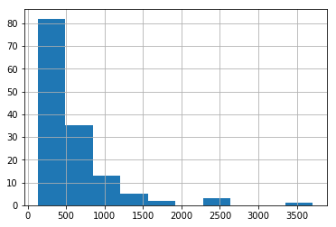

```python
data.x.hist()
```

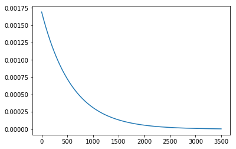

```python
import numpy as np

# Let's try an exponential distribution
# Wikipedia says the maximum likelihood estimate is the following:
# lambda_hat = n / sum(x_i, i, 1, n)
def river_exp(x):
    if river_exp.lambda_hat == None:
        river_exp.lambda_hat = float(data.count()[0]) / np.sum([cur for cur in data['x']])
    return river_exp.lambda_hat * (math.e ** (-river_exp.lambda_hat * x))
river_exp.lambda_hat = None

x = np.arange(0, 3500, 0.1)
y = [river_exp(i) for i in x]

plt.plot(x, y)
```

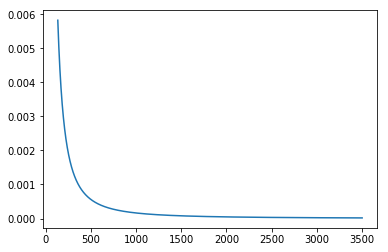

```python
# Let's try a Pareto distribution.
# Wikipedia says the maximum likelihood estimate is the following:
# x_m_hat = min(x_i)
# alpha_hat = n / (sum(ln(x_i) - ln(x_m_hat), i, 1, n))
# PDF = (alpha * x_m ^ alpha) / (x ^ (alpha + 1))
def river_pareto(x):
    if river_pareto.x_m_hat == None:
        river_pareto.x_m_hat = data['x'].min()
        x_m_hat_log = math.log(river_pareto.x_m_hat)
        river_pareto.alpha_hat = float(data.count()[0]) / np.sum([math.log(cur) - x_m_hat_log for cur in data['x']])
    # Undefined for x < x_m_hat
    if x < river_pareto.x_m_hat:
        raise ValueError('Pareto is only defined for x >= x_m. Expected x >= ' + str(river_pareto.x_m_hat) + ". Got x = " + str(x))
    return (river_pareto.alpha_hat * float(river_pareto.x_m_hat) ** river_pareto.alpha_hat) / (x ** (river_pareto.alpha_hat + 1))
river_pareto.x_m_hat = None
river_pareto.alpha_hat = None

x = np.arange(135, 3500, 0.1)
y = [river_pareto(i) for i in x]

plt.plot(x, y)
```

```python
def entropy(function, samples):
    return -np.sum([function(cur) * math.log(function(cur)) for cur in samples])
```

```python
entropy(river_exp, data['x'])
```

```
0.7503477738108656
```

```python
entropy(river_pareto, data['x'])
```

```
0.8625268286684447
```

By the law of maximum entropy, it appears that the pareto distribution is a better fit for this data than the exponential distribution

```python
def k_l_div(function_1, function_2, samples):
    return np.sum([function_1(cur) * (math.log(function_1(cur)) - math.log(function_2(cur))) for cur in data['x']])
```

```python
# The result indicates that the exponential distribution is less entropic compared to the pareto distribution
k_l_div(river_exp, river_pareto, data['x'])
```

```
-0.011136467118415927
```

```python
# The result indicates that the pareto distribution is more entropic compared to the exponential distribution
k_l_div(river_pareto, river_exp, data['x'])
```

```
0.03843558643689944
```

As expected, the relative entropy (K-L Div.) of the pareto distribution w.r.t. the exponential distribution is positive, and the relative entropy of the exponential distribution w.r.t. the pareto distribution is negative.